# Correlation

ozge.ozdamar@msgsu.edu.tr

October 28 2021

[figure not shown]

MSGSU ISTATISTIK BOLUMU - R ILE ISTATISTIKSEL PROGRAMLAMA DERS NOTLARI 2021 by ozge.ozdamar@msgsu.edu.tr is licensed under a [Creative Commons Attribution-NonCommercial-ShareAlike 4.0 International License](http://creativecommons.org/licenses/by-nc-sa/4.0/).

**REFERENCES**

**LIBRARIES**

```r
rm(list=ls())
.packages = c("corrplot","PerformanceAnalytics","corrgram","plotrix", "Hmisc","gclus","polycor","psych", "corr")
.inst <- .packages %in% installed.packages()
if(length(.packages[!.inst]) > 0) install.packages(.packages[!.inst])
lapply(.packages, require, character.only=TRUE)
```

**FUNCTIONS**

```r
stats::cor(), cor.test(), cov(), symnum()
corrplot::corrplot()
PerformanceAnaltics::
corrgram::corrgram()
plotrix::
Hmisc::rcorr()
gclus::
```

**data**

```r
head(mtcars)
```

|  | mpg | cyl | disp | hp | drat | wt | qsec | vs | am | gear | carb |
| --- | --- | --- | --- | --- | --- | --- | --- | --- | --- | --- | --- |
| Mazda RX4 | 21.0 | 6 | 160 | 110 | 3.90 | 2.620 | 16.46 | 0 | 1 | 4 | 4 |
| Mazda RX4 Wag | 21.0 | 6 | 160 | 110 | 3.90 | 2.875 | 17.02 | 0 | 1 | 4 | 4 |
| Datsun 710 | 22.8 | 4 | 108 | 93 | 3.85 | 2.320 | 18.61 | 1 | 1 | 4 | 1 |
| Hornet 4 Drive | 21.4 | 6 | 258 | 110 | 3.08 | 3.215 | 19.44 | 1 | 0 | 3 | 1 |
| Hornet Sportabout | 18.7 | 8 | 360 | 175 | 3.15 | 3.440 | 17.02 | 0 | 0 | 3 | 2 |
| Valiant | 18.1 | 6 | 225 | 105 | 2.76 | 3.460 | 20.22 | 1 | 0 | 3 | 1 |

# 1 Correlation - covariance

Pearson correlation (r): measures a linear dependence between two variables. It is also known as a parametric correlation test because it depends to the distribution of the data. It can be used only when x and y are from normal distribution.

Kendall tau and Spearman rho, which are rank-based correlation coefficients (non-parametric)

```r
cor(x, y, method = c("pearson", "kendall", "spearman"))
cor.test(x, y, method=c("pearson", "kendall", "spearman"))
cov(mtcars, use="complete.obs") # korelasyon
```

```r
cor(mtcars$mpg,mtcars$disp)
```

```
## [1] -0.8475514
```

```r
cor(mtcars$mpg,mtcars$disp,mtcars$hp) #! invalid
```

```r
cor(mtcars[,c(1,3,4)])
```

```
##             mpg       disp         hp
## mpg   1.0000000 -0.8475514 -0.7761684
## disp -0.8475514  1.0000000  0.7909486
## hp   -0.7761684  0.7909486  1.0000000
```

```r
cor(mtcars)
```

```
##             mpg        cyl       disp         hp        drat         wt
## mpg   1.0000000 -0.8521620 -0.8475514 -0.7761684  0.68117191 -0.8676594
## cyl  -0.8521620  1.0000000  0.9020329  0.8324475 -0.69993811  0.7824958
## disp -0.8475514  0.9020329  1.0000000  0.7909486 -0.71021393  0.8879799
## hp   -0.7761684  0.8324475  0.7909486  1.0000000 -0.44875912  0.6587479
## drat  0.6811719 -0.6999381 -0.7102139 -0.4487591  1.00000000 -0.7124406
## wt   -0.8676594  0.7824958  0.8879799  0.6587479 -0.71244065  1.0000000
## qsec  0.4186840 -0.5912421 -0.4336979 -0.7082234  0.09120476 -0.1747159
## vs    0.6640389 -0.8108118 -0.7104159 -0.7230967  0.44027846 -0.5549157
## am    0.5998324 -0.5226070 -0.5912270 -0.2432043  0.71271113 -0.6924953
## gear  0.4802848 -0.4926866 -0.5555692 -0.1257043  0.69961013 -0.5832870
## carb -0.5509251  0.5269883  0.3949769  0.7498125 -0.09078980  0.4276059
##             qsec         vs          am       gear        carb
## mpg   0.41868403  0.6640389  0.59983243  0.4802848 -0.55092507
## cyl  -0.59124207 -0.8108118 -0.52260705 -0.4926866  0.52698829
## disp -0.43369788 -0.7104159 -0.59122704 -0.5555692  0.39497686
## hp   -0.70822339 -0.7230967 -0.24320426 -0.1257043  0.74981247
## drat  0.09120476  0.4402785  0.71271113  0.6996101 -0.09078980
## wt   -0.17471588 -0.5549157 -0.69249526 -0.5832870  0.42760594
## qsec  1.00000000  0.7445354 -0.22986086 -0.2126822 -0.65624923
## vs    0.74453544  1.0000000  0.16834512  0.2060233 -0.56960714
## am   -0.22986086  0.1683451  1.00000000  0.7940588  0.05753435
## gear -0.21268223  0.2060233  0.79405876  1.0000000  0.27407284
## carb -0.65624923 -0.5696071  0.05753435  0.2740728  1.00000000
```

```r
cor(mtcars[,c(2,10)],method = "spearman")
```

```
##             cyl       gear
## cyl   1.0000000 -0.5643105
## gear -0.5643105  1.0000000
```

covariance

```r
cov(mtcars)
```

```
##              mpg         cyl        disp          hp         drat          wt
## mpg    36.324103  -9.1723790  -633.09721 -320.732056   2.19506351  -5.1166847
## cyl    -9.172379   3.1895161   199.66028  101.931452  -0.66836694   1.3673710
## disp -633.097208 199.6602823 15360.79983 6721.158669 -47.06401915 107.6842040
## hp   -320.732056 101.9314516  6721.15867 4700.866935 -16.45110887  44.1926613
## drat    2.195064  -0.6683669   -47.06402  -16.451109   0.28588135  -0.3727207
## wt     -5.116685   1.3673710   107.68420   44.192661  -0.37272073   0.9573790
## qsec    4.509149  -1.8868548   -96.05168  -86.770081   0.08714073  -0.3054816
## vs      2.017137  -0.7298387   -44.37762  -24.987903   0.11864919  -0.2736613
## am      1.803931  -0.4657258   -36.56401   -8.320565   0.19015121  -0.3381048
## gear    2.135685  -0.6491935   -50.80262   -6.358871   0.27598790  -0.4210806
## carb   -5.363105   1.5201613    79.06875   83.036290  -0.07840726   0.6757903
##              qsec           vs           am        gear        carb
## mpg    4.50914919   2.01713710   1.80393145   2.1356855 -5.36310484
## cyl   -1.88685484  -0.72983871  -0.46572581  -0.6491935  1.52016129
## disp -96.05168145 -44.37762097 -36.56401210 -50.8026210 79.06875000
## hp   -86.77008065 -24.98790323  -8.32056452  -6.3588710 83.03629032
## drat   0.08714073   0.11864919   0.19015121   0.2759879 -0.07840726
## wt    -0.30548161  -0.27366129  -0.33810484  -0.4210806  0.67579032
## qsec   3.19316613   0.67056452  -0.20495968  -0.2804032 -1.89411290
## vs     0.67056452   0.25403226   0.04233871   0.0766129 -0.46370968
## am    -0.20495968   0.04233871   0.24899194   0.2923387  0.04637097
## gear  -0.28040323   0.07661290   0.29233871   0.5443548  0.32661290
## carb  -1.89411290  -0.46370968   0.04637097   0.3266129  2.60887097
```

heterogeneous correlations in one matrix

pearson (numeric-numeric) polyserial (numeric-ordinal) polychoric (ordinal-ordinal)

x is a data frame with ordered factors and numeric variables

library polycor

```r
polycor::hetcor(mtcars)
```

```
##
## Two-Step Estimates
##
## Correlations/Type of Correlation:
##          mpg     cyl    disp      hp     drat      wt    qsec      vs      am
## mpg        1 Pearson Pearson Pearson  Pearson Pearson Pearson Pearson Pearson
## cyl  -0.8522       1 Pearson Pearson  Pearson Pearson Pearson Pearson Pearson
## disp -0.8476   0.902       1 Pearson  Pearson Pearson Pearson Pearson Pearson
## hp   -0.7762  0.8324  0.7909       1  Pearson Pearson Pearson Pearson Pearson
## drat  0.6812 -0.6999 -0.7102 -0.4488        1 Pearson Pearson Pearson Pearson
## wt   -0.8677  0.7825   0.888  0.6587  -0.7124       1 Pearson Pearson Pearson
## qsec  0.4187 -0.5912 -0.4337 -0.7082   0.0912 -0.1747       1 Pearson Pearson
## vs     0.664 -0.8108 -0.7104 -0.7231   0.4403 -0.5549  0.7445       1 Pearson
## am    0.5998 -0.5226 -0.5912 -0.2432   0.7127 -0.6925 -0.2299  0.1683       1
## gear  0.4803 -0.4927 -0.5556 -0.1257   0.6996 -0.5833 -0.2127   0.206  0.7941
## carb -0.5509   0.527   0.395  0.7498 -0.09079  0.4276 -0.6562 -0.5696 0.05753
##         gear    carb
## mpg  Pearson Pearson
## cyl  Pearson Pearson
## disp Pearson Pearson
## hp   Pearson Pearson
## drat Pearson Pearson
## wt   Pearson Pearson
## qsec Pearson Pearson
## vs   Pearson Pearson
## am   Pearson Pearson
## gear       1 Pearson
## carb  0.2741       1
##
## Standard Errors:
##          mpg     cyl    disp      hp    drat      wt    qsec     vs      am
## mpg
## cyl  0.04919
## disp 0.05059 0.03353
## hp   0.07124 0.05512 0.06712
## drat 0.09575 0.09118 0.08861  0.1418
## wt   0.04443 0.06949 0.03804   0.101 0.08805
## qsec  0.1463  0.1159  0.1441 0.08911  0.1751  0.1713
## vs   0.09982 0.06146 0.08856 0.08535  0.1431  0.1232 0.07977
## am    0.1141  0.1293  0.1159  0.1664 0.08799 0.09301  0.1675 0.1717
```

[output cut: 27 more lines]

```
## am   7.773e-06  1.82e-08 3.823e-06 1.024e-05 3.139e-08  1.67e-07 6.433e-06
## gear 0.0004057 7.266e-07 6.619e-05 3.128e-05 2.053e-05 0.0006289 8.958e-05
## carb     0.448 2.714e-05  0.005671   0.03627  0.006825   0.06127    0.1162
##             vs        am      gear
## mpg
## cyl
## disp
## hp
## drat
## wt
## qsec
## vs
## am   4.349e-13
## gear 5.559e-11 4.483e-09
## carb 7.788e-07  4.58e-07 0.0001869
```

```r
polycor::polyserial(mtcars$cyl,mtcars$carb)
```

```
## [1] 0.6137757
```

```r
polycor::polychor(mtcars$cyl,mtcars$carb)
```

```
## [1] 0.6221268
```

**Hmisc::rcorr()**

```r
# rcorr(x, y, type=c("pearson","spearman")) # with P values
```

```r
Hmisc::rcorr(as.matrix(mtcars))
```

```
##        mpg   cyl  disp    hp  drat    wt  qsec    vs    am  gear  carb
## mpg   1.00 -0.85 -0.85 -0.78  0.68 -0.87  0.42  0.66  0.60  0.48 -0.55
## cyl  -0.85  1.00  0.90  0.83 -0.70  0.78 -0.59 -0.81 -0.52 -0.49  0.53
## disp -0.85  0.90  1.00  0.79 -0.71  0.89 -0.43 -0.71 -0.59 -0.56  0.39
## hp   -0.78  0.83  0.79  1.00 -0.45  0.66 -0.71 -0.72 -0.24 -0.13  0.75
## drat  0.68 -0.70 -0.71 -0.45  1.00 -0.71  0.09  0.44  0.71  0.70 -0.09
## wt   -0.87  0.78  0.89  0.66 -0.71  1.00 -0.17 -0.55 -0.69 -0.58  0.43
## qsec  0.42 -0.59 -0.43 -0.71  0.09 -0.17  1.00  0.74 -0.23 -0.21 -0.66
## vs    0.66 -0.81 -0.71 -0.72  0.44 -0.55  0.74  1.00  0.17  0.21 -0.57
## am    0.60 -0.52 -0.59 -0.24  0.71 -0.69 -0.23  0.17  1.00  0.79  0.06
## gear  0.48 -0.49 -0.56 -0.13  0.70 -0.58 -0.21  0.21  0.79  1.00  0.27
## carb -0.55  0.53  0.39  0.75 -0.09  0.43 -0.66 -0.57  0.06  0.27  1.00
##
## n= 32
##
##
## P
##      mpg    cyl    disp   hp     drat   wt     qsec   vs     am     gear
## mpg         0.0000 0.0000 0.0000 0.0000 0.0000 0.0171 0.0000 0.0003 0.0054
## cyl  0.0000        0.0000 0.0000 0.0000 0.0000 0.0004 0.0000 0.0022 0.0042
## disp 0.0000 0.0000        0.0000 0.0000 0.0000 0.0131 0.0000 0.0004 0.0010
## hp   0.0000 0.0000 0.0000        0.0100 0.0000 0.0000 0.0000 0.1798 0.4930
## drat 0.0000 0.0000 0.0000 0.0100        0.0000 0.6196 0.0117 0.0000 0.0000
## wt   0.0000 0.0000 0.0000 0.0000 0.0000        0.3389 0.0010 0.0000 0.0005
## qsec 0.0171 0.0004 0.0131 0.0000 0.6196 0.3389        0.0000 0.2057 0.2425
## vs   0.0000 0.0000 0.0000 0.0000 0.0117 0.0010 0.0000        0.3570 0.2579
## am   0.0003 0.0022 0.0004 0.1798 0.0000 0.0000 0.2057 0.3570        0.0000
## gear 0.0054 0.0042 0.0010 0.4930 0.0000 0.0005 0.2425 0.2579 0.0000
## carb 0.0011 0.0019 0.0253 0.0000 0.6212 0.0146 0.0000 0.0007 0.7545 0.1290
##      carb
## mpg  0.0011
## cyl  0.0019
## disp 0.0253
## hp   0.0000
## drat 0.6212
## wt   0.0146
## qsec 0.0000
## vs   0.0007
## am   0.7545
## gear 0.1290
## carb
```

# 2 check the test assumptions

1. Is the covariation linear?
2. (x, y) follow a normal distribution? Use Shapiro-Wilk normality test, R function: shapiro.test()

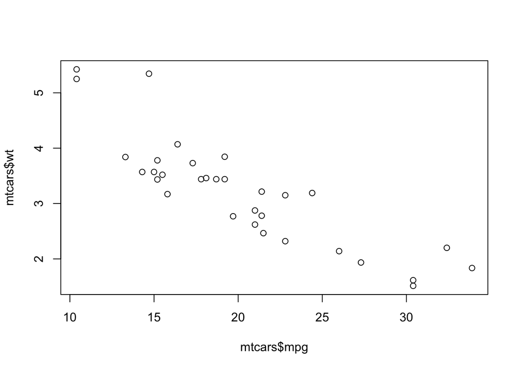

```r
plot(mtcars$mpg,mtcars$wt)
```

Shapiro-Wilk test can be performed as follow: H0: the data are normally distributed H1: the data are not normally distributed

Shapiro-Wilk normality test for mpg

```r
shapiro.test(mtcars$mpg) # => p = 0.1229
```

```
##
##  Shapiro-Wilk normality test
##
## data:  mtcars$mpg
## W = 0.94756, p-value = 0.1229
```

Shapiro-Wilk normality test for wt

```r
shapiro.test(mtcars$wt) # => p = 0.09
```

```
##
##  Shapiro-Wilk normality test
##
## data:  mtcars$wt
## W = 0.94326, p-value = 0.09265
```

From the output, the two p-values are greater than the significance level 0.05 implying that the distribution of the data are not significantly different from normal distribution. In other words, we can assume the normality.

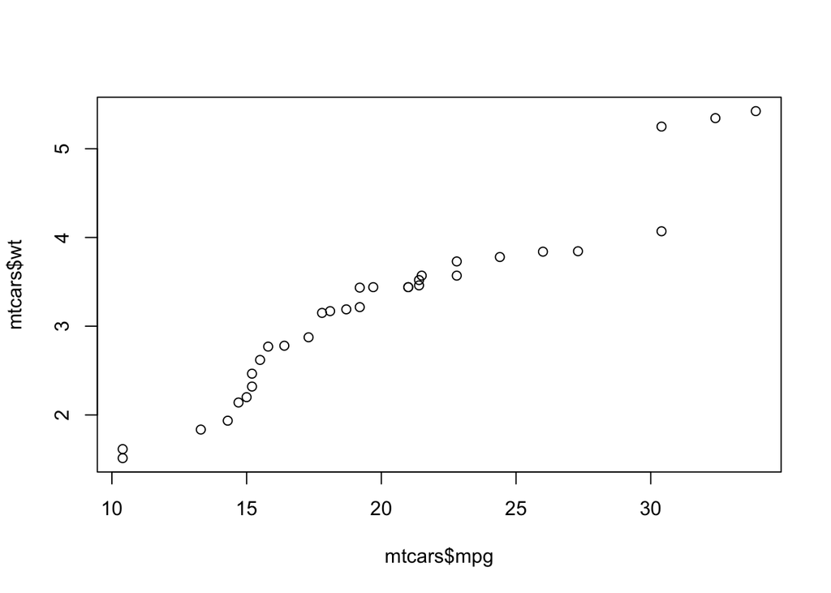

```r
qqplot(mtcars$mpg,mtcars$wt)
```

# 3 correlation test

```r
cor.test(x,y,method=c("pearson","kendall","spearman"))
```

```r
cor.test(mtcars$mpg,mtcars$wt)
```

```
##
##  Pearson's product-moment correlation
##
## data:  mtcars$mpg and mtcars$wt
## t = -9.559, df = 30, p-value = 1.294e-10
## alternative hypothesis: true correlation is not equal to 0
## 95 percent confidence interval:
##  -0.9338264 -0.7440872
## sample estimates:
##        cor
## -0.8676594
```

# 4 big correlation matrix

http://search.r-project.org/library/HiClimR/html/fastCor.html

https://www.r-bloggers.com/2013/02/bigcor-large-correlation-matrices-in-r/

# 5 Visualization correlation matrix

```r
KOR<-cor(mtcars)
```

symnum() graph

```r
symnum(KOR, cutpoints = c(-1, -0.6, 0, 0.6, 1),
       symbols = c(" ", ".", "+", "*"), abbr.colnames = TRUE)
```

```
##      m cy ds h dr w q v a g cr
## mpg  *         *    + * + + .
## cyl    *  *  *    * .   . . +
## disp   *  *  *    * .   . . +
## hp     *  *  * .  *     . . *
## drat *       . *    + + * * .
## wt     *  *  *    * . .   . +
## qsec + .  .    +  . * * . .
## vs   *         +  . * * + + .
## am   + .  .  . *    . + * * +
## gear + .  .  . *  . . + * * +
## carb . +  +  * .  +   . + + *
## attr(,"legend")
## [1] -1 ' ' -0.6 '.' 0 '+' 0.6 '*' 1
```

**corrplot::corrplot()**

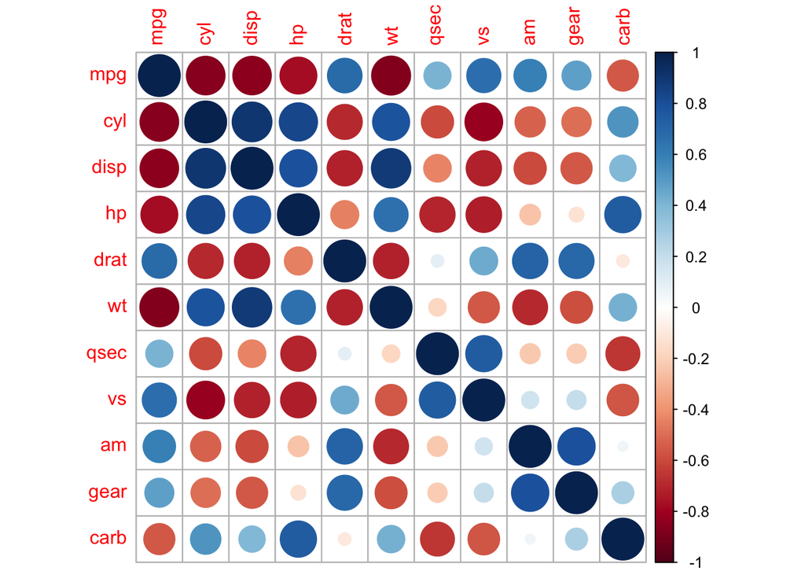

```r
corrplot::corrplot(KOR)
```

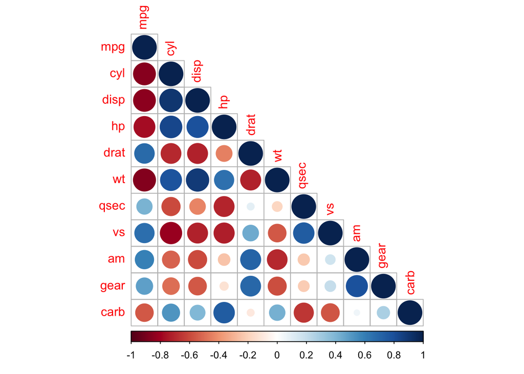

```r
corrplot::corrplot(KOR, method="circle", type="lower")
```

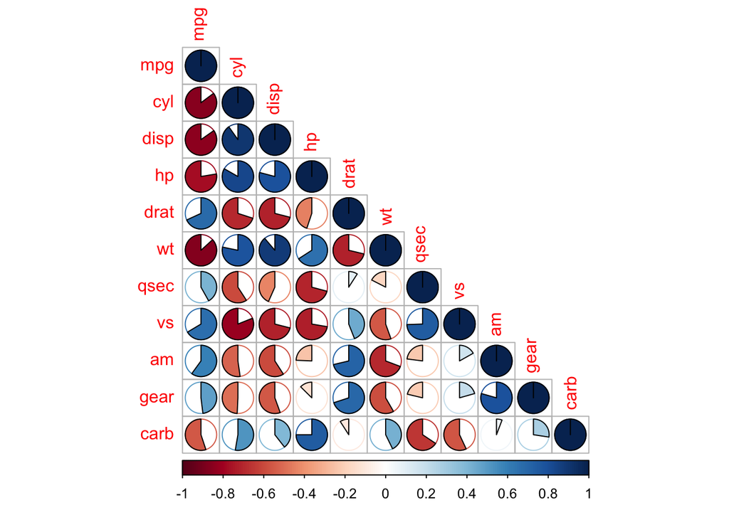

```r
corrplot::corrplot(KOR, method="pie", type="lower")
```

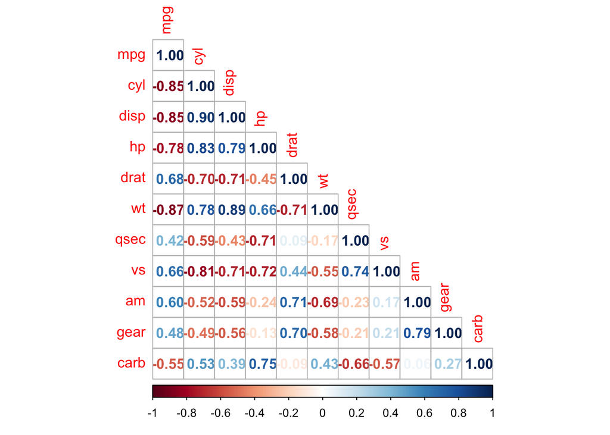

```r
corrplot::corrplot(KOR, method="number", type="lower")
```

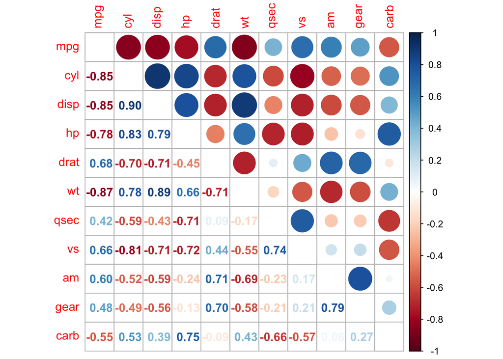

```r
corrplot::corrplot.mixed(KOR, lower="number", upper="circle",tl.pos="lt")
```

**PerformanceAnalytics::chart.Correlation**

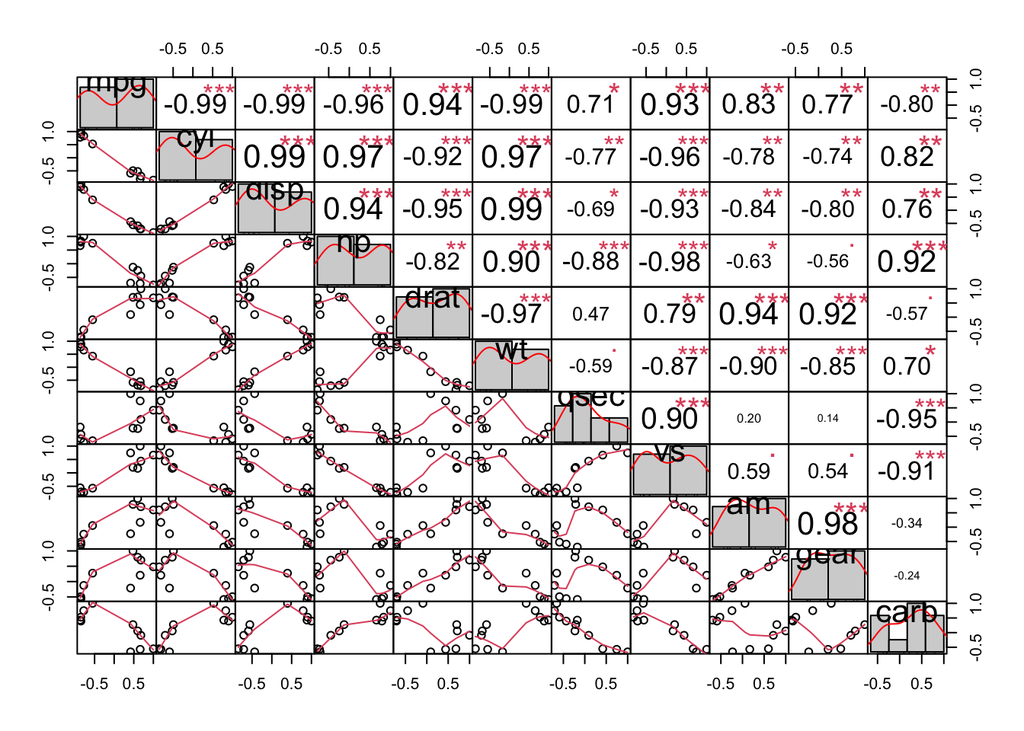

```r
PerformanceAnalytics::chart.Correlation(KOR, method="pearson", histogram=TRUE)
```

**corrgram::corrgram()**

[figure not shown]

```r
corrgram::corrgram(KOR)
```

```r
corrgram::corrgram(KOR, order=TRUE, lower.panel=panel.shade, upper.panel=panel.pie, text.panel=panel.txt, main="KOR")
```

[output not shown]

**gclus::**

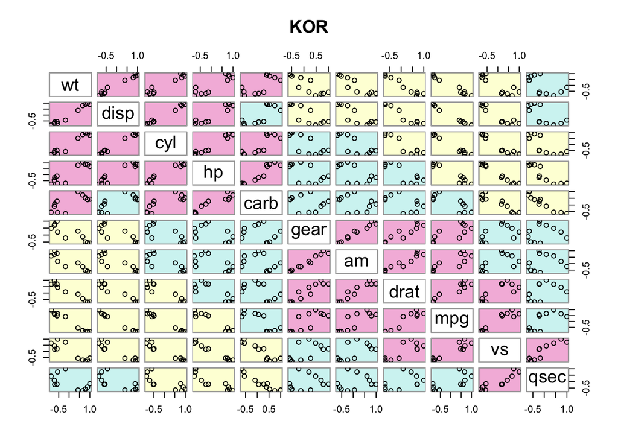

```r
COL.KOR<-gclus::dmat.color(KOR)
ORD.KOR<- gclus::order.single(KOR)
gclus::cpairs(KOR, ORD.KOR, panel.colors=COL.KOR, gap=.5, main="KOR")
```